# STAA 577: Laboratory Nine Support Vector Machines (`tidyverse`)

Adapted by Tavener & Field From: James, Witten, Hastie and Tibshirani

14 January 2019

### Load necessary libraries

```r
options(warnPartialMatchArgs = FALSE)  # don't want these warnings
library(magrittr)     # pipes
library(tibble)       # tibbles
library(dplyr)        # data wrangling
library(purrr)        # iteration
library(yardstick)    # classification performance measures
library(ggplot2)      # tidy plotting
library(ISLR)         # The `Carseats` data set
library(e1071)        # package for SVMs (but also naive Bayes)
library(pROC)         # ROC curves
```

# 1 Create training data

```r
set.seed(1)
sim_data <- matrix(rnorm(20 * 2), ncol = 2) %>%  #    20x2 matrix of random gaussian N~(0,1)
  data.frame() %>%                           # convert to data frame
  magrittr::set_names(c("F1", "F2")) %>%     # name 2 features F1 & F2
  dplyr::mutate(y = c(rep(-1, 10), rep(1, 10))) %>%   # add a class variable (-1, 1)
  dplyr::mutate(F1 = ifelse(y == 1, F1 + 1, F1),      # add +1 to F1 for class +1
                F2 = ifelse(y == 1, F2 + 1, F2),      # add +1 to F2 for class +1
                y  = factor(y)) %>%         # make classes factor for model building
  tibble::as.tibble()                       # convert to tibble
sim_data
```

| F1 | F2 | y |
| --- | --- | --- |
| -0.6264538 | 0.91897737 | -1 |
| 0.1836433 | 0.78213630 | -1 |
| -0.8356286 | 0.07456498 | -1 |
| 1.5952808 | -1.98935170 | -1 |
| 0.3295078 | 0.61982575 | -1 |
| -0.8204684 | -0.05612874 | -1 |
| 0.4874291 | -0.15579551 | -1 |
| 0.7383247 | -1.47075238 | -1 |
| 0.5757814 | -0.47815006 | -1 |
| -0.3053884 | 0.41794156 | -1 |

[output cut: 10 more lines]

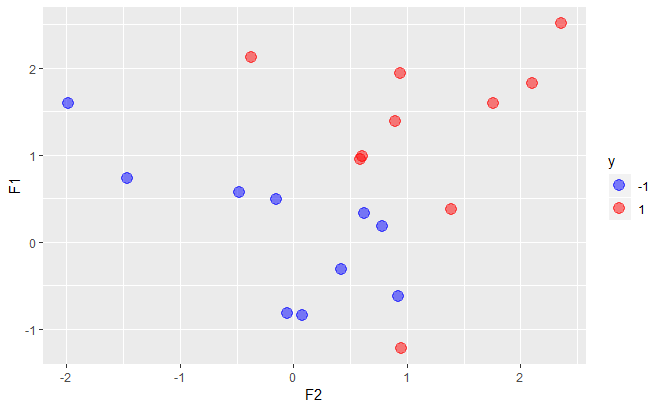

```r
sim_data %>%
  ggplot(aes(x = F2, y = F1, colour = y)) +   # flip axes to match SVM plot method; F2 on `x`
  geom_point(alpha = 0.5, size = 4) +
  scale_colour_manual(values = c("blue", "red")) +
  NULL
```

# 2 Support Vector Classifier

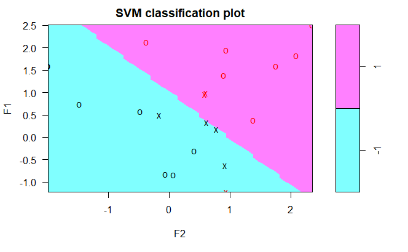

```r
# Cost of constraint violation = 10
svmfit1 <- e1071::svm(y ~ ., data = sim_data, kernel = "linear",
                     cost = 10, scale = FALSE)
# Support vectors are plotted as crosses, others as circles
# One point is misclassified at (x1, x2) ~= (-1.2, 1)
plot(svmfit1, sim_data)      # built-in S3 plot method class `svm`
```

```r
# The support vectors are listed by index
summary(svmfit1)
```

```
Call:
svm(formula = y ~ ., data = sim_data, kernel = "linear", cost = 10,
    scale = FALSE)


Parameters:
   SVM-Type:  C-classification
 SVM-Kernel:  linear
       cost:  10
      gamma:  0.5

Number of Support Vectors:  7

 ( 4 3 )


Number of Classes:  2

Levels:
 -1 1
```

```r
svmfit1$index
```

```
[1]  1  2  5  7 14 16 17
```

```r
svmfit1$SV
```

```
           F1         F2
1  -0.6264538  0.9189774
2   0.1836433  0.7821363
5   0.3295078  0.6198257
7   0.4874291 -0.1557955
14 -1.2146999  0.9461950
16  0.9550664  0.5850054
17  0.9838097  0.6057100
```

```r
svmfit1$coefs
```

```
           [,1]
[1,]   5.001674
[2,]  10.000000
[3,]  10.000000
[4,]   2.476688
[5,] -10.000000
[6,] -10.000000
[7,]  -7.478362
```

**NOTE**: These coefficients are Lagrange multipliers for the inequality constraints when the SV classifier is posed as a quadratic programming problem. Through a consideration of the optimality conditions, they indicate which of the support vectors lie on the margin and which lie within the margin. For example, point 2, 5, 14 and 16 lie WITHIN the margin and their coefficients have magnitude equal to the cost. (The coefficients are multiplied by the training labels, hence the positive and negative values). Points 1, 7, and 17 have a coefficient with magnitude less than the cost and lie ON the margin.

### 2.1.1 Challenge Exercise

The plots above and below were generated via the S3 plot method for objects of class `svm` written in `base R` plotting. Create your own `S3 ggplot method` for class `svm` that produces a similar plot using `ggplot` style graphics. **Hint**: it should be called `ggplot.svm` and is invoked via a call like this:

```r
ggplot(svmfit2)
```

## 2.2 Fitting SVM: `cost = 0.1`

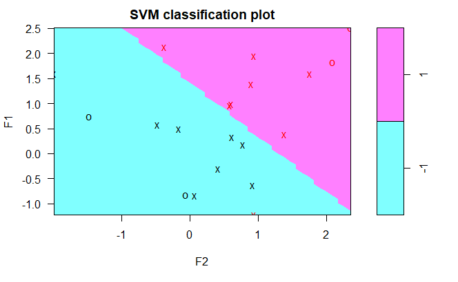

```r
# Cost of constraints violation = 0.1
svmfit2 <- e1071::svm(y ~ ., data = sim_data, kernel = "linear",
                      cost = 0.1, scale = FALSE)
plot(svmfit2, sim_data)
```

```r
summary(svmfit2)
```

```
Call:
svm(formula = y ~ ., data = sim_data, kernel = "linear", cost = 0.1,
    scale = FALSE)


Parameters:
   SVM-Type:  C-classification
 SVM-Kernel:  linear
       cost:  0.1
      gamma:  0.5

Number of Support Vectors:  16

 ( 8 8 )


Number of Classes:  2

Levels:
 -1 1
```

```r
svmfit2$index
```

```
 [1]  1  2  3  4  5  7  9 10 12 13 14 15 16 17 18 20
```

```r
svmfit2$SV
```

```
           F1          F2
1  -0.6264538  0.91897737
2   0.1836433  0.78213630
3  -0.8356286  0.07456498
4   1.5952808 -1.98935170
5   0.3295078  0.61982575
7   0.4874291 -0.15579551
9   0.5757814 -0.47815006
10 -0.3053884  0.41794156
12  1.3898432  0.89721227
13  0.3787594  1.38767161
14 -1.2146999  0.94619496
15  2.1249309 -0.37705956
16  0.9550664  0.58500544
17  0.9838097  0.60571005
18  1.9438362  0.94068660
20  1.5939013  1.76317575
```

```r
svmfit2$coefs
```

```
             [,1]
 [1,]  0.10000000
 [2,]  0.10000000
 [3,]  0.01458676
 [4,]  0.10000000
 [5,]  0.10000000
 [6,]  0.10000000
 [7,]  0.10000000
 [8,]  0.10000000
 [9,] -0.10000000
[10,] -0.10000000
[11,] -0.10000000
[12,] -0.10000000
[13,] -0.10000000
[14,] -0.10000000
[15,] -0.10000000
[16,] -0.01458676
```

**NOTE**: Many more support vectors, most of which lie WITHIN the margin.

## 2.3 Select the best cost of constraints by cross validation

```r
# Tune support vector classifier to find best cost of constraints
set.seed(1)
tune_out <- e1071::tune(svm, y ~ ., data = sim_data, kernel = "linear",
                        ranges = list(cost = c(0.001, 0.01, 0.1, 1, 5, 10, 100)))
summary(tune_out)
```

```
Parameter tuning of svm:

- sampling method: 10-fold cross validation

- best parameters:
```

|  | cost |
| --- | --- |
|  | 0.1 |

```
- best performance: 0.1

- Detailed performance results:
```

| cost | error | dispersion |
| --- | --- | --- |
| 1e-03 | 0.70 | 0.4216370 |
| 1e-02 | 0.70 | 0.4216370 |
| 1e-01 | 0.10 | 0.2108185 |
| 1e+00 | 0.15 | 0.2415229 |
| 5e+00 | 0.15 | 0.2415229 |
| 1e+01 | 0.15 | 0.2415229 |
| 1e+02 | 0.15 | 0.2415229 |

```r
# Save the best model
bestmod <- tune_out$best.model
summary(bestmod)
```

```
Call:
best.tune(method = svm, train.x = y ~ ., data = sim_data, ranges = list(cost = c(0.001,
    0.01, 0.1, 1, 5, 10, 100)), kernel = "linear")


Parameters:
   SVM-Type:  C-classification
 SVM-Kernel:  linear
       cost:  0.1
      gamma:  0.5

Number of Support Vectors:  16

 ( 8 8 )


Number of Classes:  2

Levels:
 -1 1
```

## 2.4 Create new test data

```r
sim_test <- matrix(rnorm(20 * 2), ncol = 2) %>%  # 20x2 matrix of random gaussian N~(0,1)
  data.frame() %>%                               # convert to data frame
  magrittr::set_names(c("F1", "F2")) %>%         # name 2 features F1 & F2
  dplyr::mutate(y = sample(c(-1, 1), 20,
                           replace = TRUE)) %>%       # add random class variable (-1, 1)
  dplyr::mutate(F1 = ifelse(y == 1, F1 + 1, F1),      # add +1 to F1 for class +1
                F2 = ifelse(y == 1, F2 + 1, F2),      # add +1 to F2 for class +1
                y  = factor(y)) %>%         # make classes factor for model building
  tibble::as.tibble()                       # convert to tibble
sim_test
```

| F1 | F2 | y |
| --- | --- | --- |
| 2.51178117 | 2.3586796 | 1 |
| 0.38984324 | -0.1027877 | -1 |
| -0.62124058 | 0.3876716 | -1 |
| -1.21469989 | 0.9461950 | 1 |
| 2.12493092 | -0.3770596 | 1 |
| -0.04493361 | -0.4149946 | -1 |
| -0.01619026 | -0.3942900 | -1 |
| 0.94383621 | -0.0593134 | -1 |
| 1.82122120 | 2.1000254 | 1 |
| 1.59390132 | 1.7631757 | 1 |

[output cut: 10 more lines]

### 2.4.1 Predict using best cost

```r
# Predict using the `best model`
best_pred_test_df <- data.frame(
  true_class      = sim_test$y,
  predicted_class = predict(bestmod, newdata = sim_test)
)
best_pred_test_df %>%
  yardstick::conf_mat(truth = true_class, estimate = predicted_class)
```

```
          Truth
Prediction -1  1
        -1 11  1
        1   0  8
```

```r
best_pred_test_df %>%
  yardstick::accuracy(truth = true_class, estimate = predicted_class) %>%
  purrr::pluck(".estimate")
```

```
[1] 0.95
```

### 2.4.2 Predict using small cost

```r
# Fit and test using cost of constraint violation = 0.01
svmfit3 <- e1071::svm(y ~ ., data = sim_data, kernel = "linear",
                      cost = 0.01, scale = FALSE)
constraint_pred_test_df <- data.frame(
  true_class      = sim_test$y,
  predicted_class = predict(svmfit3, newdata = sim_test)
)
constraint_pred_test_df %>%
  yardstick::conf_mat(truth = true_class, estimate = predicted_class)
```

```
          Truth
Prediction -1  1
        -1 11  2
        1   0  7
```

```r
constraint_pred_test_df %>%
  yardstick::accuracy(truth = true_class, estimate = predicted_class) %>%
  purrr::pluck(".estimate")
```

```
[1] 0.9
```

## 2.5 Linearly Separable Data

```r
# Create linearly separable data
set.seed(1)
linsep_data <- matrix(rnorm(20 * 2), ncol = 2) %>%
  data.frame() %>%                           # convert to data frame
  magrittr::set_names(c("F1", "F2")) %>%     # name 2 features F1 & F2
  dplyr::mutate(y = c(rep(-1, 10), rep(1, 10))) %>%   # add a class variable (-1, 1)
  dplyr::mutate(F1 = ifelse(y == 1, F1 + 1.5, F1),    # add +1.5 to F1 for class +1
                F2 = ifelse(y == 1, F2 + 1.5, F2),    # add +1.5 to F2 for class +1
                y  = factor(y)) %>%                   # make classes factor for model building
  tibble::as.tibble()                                 # convert to tibble
linsep_data
```

| F1 | F2 | y |
| --- | --- | --- |
| -0.6264538 | 0.91897737 | -1 |
| 0.1836433 | 0.78213630 | -1 |
| -0.8356286 | 0.07456498 | -1 |
| 1.5952808 | -1.98935170 | -1 |
| 0.3295078 | 0.61982575 | -1 |
| -0.8204684 | -0.05612874 | -1 |
| 0.4874291 | -0.15579551 | -1 |
| 0.7383247 | -1.47075238 | -1 |
| 0.5757814 | -0.47815006 | -1 |
| -0.3053884 | 0.41794156 | -1 |

[output cut: 10 more lines]

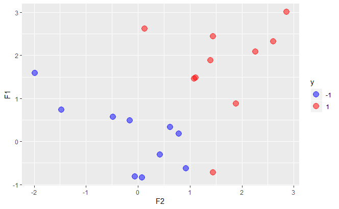

```r
linsep_data %>%
  ggplot(aes(x = F2, y = F1, colour = y)) +
  geom_point(alpha = 0.5, size = 4) +
  scale_colour_manual(values = c("blue", "red")) +
  NULL
```

```r
# Fit with cost of constraint violation = 1e5 -> no training errors
# Three support vectors: + some non support vectors very close to separating hyperplane
svmfit_c100000 <- e1071::svm(y ~ ., data = linsep_data,
                             kernel = "linear", cost = 1e05)
summary(svmfit_c100000)
```

```
Call:
svm(formula = y ~ ., data = linsep_data, kernel = "linear", cost = 1e+05)


Parameters:
   SVM-Type:  C-classification
 SVM-Kernel:  linear
       cost:  1e+05
      gamma:  0.5

Number of Support Vectors:  3

 ( 1 2 )


Number of Classes:  2

Levels:
 -1 1
```

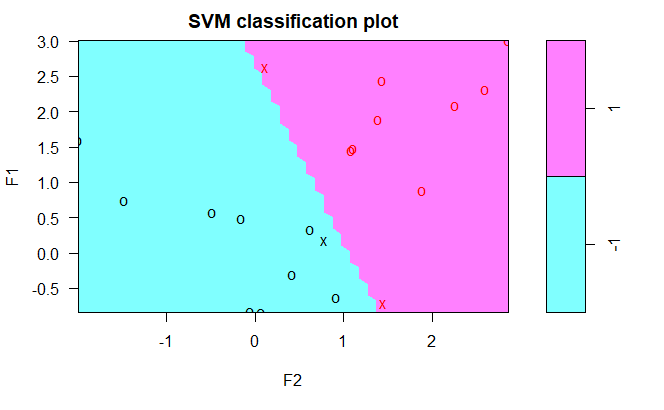

```r
plot(svmfit_c100000, linsep_data)
```

```r
# Change the cost of constraint violation = 1
# Seven support vectors -> smaller variance?
svmfit_c1 <- e1071::svm(y ~ ., data = linsep_data,
                        kernel = "linear", cost = 1)
summary(svmfit_c1)
```

```
Call:
svm(formula = y ~ ., data = linsep_data, kernel = "linear", cost = 1)


Parameters:
   SVM-Type:  C-classification
 SVM-Kernel:  linear
       cost:  1
      gamma:  0.5

Number of Support Vectors:  7

 ( 4 3 )


Number of Classes:  2

Levels:
 -1 1
```

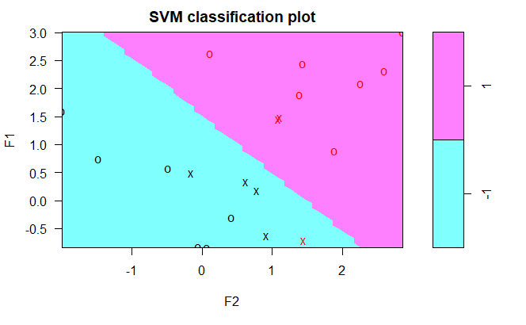

```r
plot(svmfit_c1, linsep_data)
```

# 3 The Support Vector Machine

Simulate more data, this time a 10x sized data set:

## 3.1 Two classes

```r
# Create data set
set.seed(1)
sim_data200 <- matrix(rnorm(200 * 2), ncol = 2) %>%
  data.frame() %>%                                 # convert to data frame
  magrittr::set_names(c("F1", "F2")) %>%           # name 2 features F1 & F2
  dplyr::mutate(id = dplyr::row_number()) %>%      # add index for sample ids
  dplyr::mutate(y  = rep(c(1,2), c(150,50))) %>%   # add a class variable (1, 2)
  dplyr::mutate(F1 = dplyr::case_when(                    # For F1
                       id <= 100 ~ F1 + 2,                # 1:100 -> bump +2
                       (id > 100 & id <= 150) ~ F1 - 2,   # 101:150 -> bump -2
                       TRUE ~ F1                          # 151:200 -> bump 0
                      ),
                F2 = dplyr::case_when(
                       id <= 100 ~ F2 + 2,
                       (id > 100 & id <= 150) ~ F2 - 2,
                       TRUE ~ F2
                      ),
                y  = factor(y)) %>%   # make classes factor for model building
  tibble::as.tibble() %>%             # convert to tibble
  identity()                          # similar trick as `NULL` in ggplots
sim_data200
```

| F1 | F2 | id | y |
| --- | --- | --- | --- |
| 1.37354619 | 2.4094018397 | 1 | 1 |
| 2.18364332 | 3.6888732862 | 2 | 1 |
| 1.16437139 | 3.5865884334 | 3 | 1 |
| 3.59528080 | 1.6690921993 | 4 | 1 |
| 2.32950777 | -0.2852355353 | 5 | 1 |
| 1.17953162 | 4.4976615898 | 6 | 1 |
| 2.48742905 | 2.6670661668 | 7 | 1 |
| 2.73832471 | 2.5413273360 | 8 | 1 |
| 2.57578135 | 1.9866004769 | 9 | 1 |
| 1.69461161 | 2.5101084230 | 10 | 1 |

[output cut: 190 more lines]

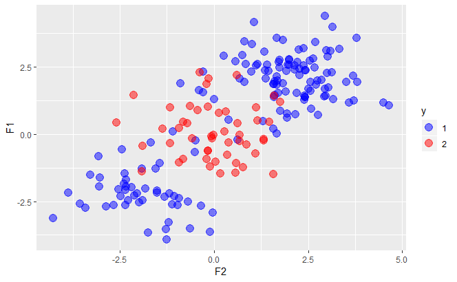

```r
sim_data200 %>%
  ggplot(aes(x = F2, y = F1, colour = y)) +
  geom_point(alpha = 0.5, size = 4) +
  scale_colour_manual(values = c("blue", "red")) +
  NULL
```

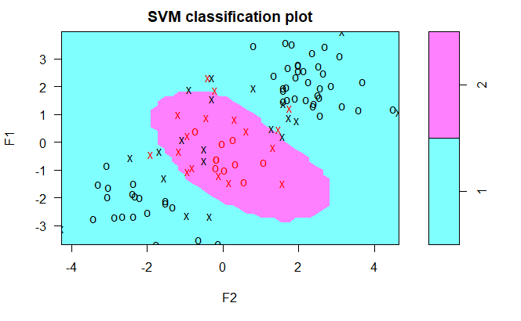

```r
# Set up training/test data using form from `Lab08`
svm_train <- sim_data200 %>%
  dplyr::sample_frac(0.5)
svm_test <- sim_data200 %>%
  dplyr::anti_join(svm_train, by = "id") %>%
  dplyr::select(-id)
svm_train %<>% dplyr::select(-id)
# Fit SVM with radial kernel and cost of constraint violation = 1
#   Gamma = parameter defining kernel
svm_radial_c1 <- e1071::svm(y ~ ., data = svm_train, kernel = "radial",
                            gamma = 1, cost = 1)
plot(svm_radial_c1, svm_train)
```

```r
summary(svm_radial_c1)
```

```
Call:
svm(formula = y ~ ., data = svm_train, kernel = "radial", gamma = 1,
    cost = 1)


Parameters:
   SVM-Type:  C-classification
 SVM-Kernel:  radial
       cost:  1
      gamma:  1

Number of Support Vectors:  37

 ( 17 20 )


Number of Classes:  2

Levels:
 1 2
```

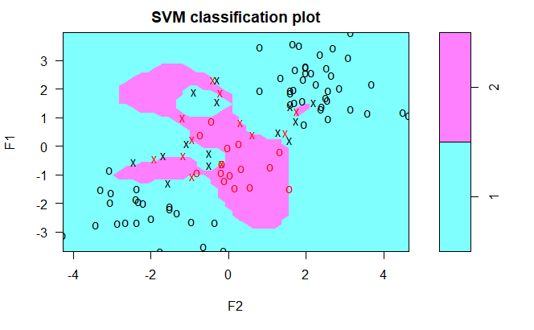

```r
# Fit SVM with radial kernel and cost of constraint violation = 1E5. Is this too much?
svm_radial_c100000 <- e1071::svm(y ~ ., data = svm_train,
                                 kernel = "radial", gamma = 1, cost = 1e5)
plot(svm_radial_c100000, svm_train)
```

```r
summary(svm_radial_c100000)
```

```
Call:
svm(formula = y ~ ., data = svm_train, kernel = "radial", gamma = 1,
    cost = 1e+05)


Parameters:
   SVM-Type:  C-classification
 SVM-Kernel:  radial
       cost:  1e+05
      gamma:  1

Number of Support Vectors:  26

 ( 12 14 )


Number of Classes:  2

Levels:
 1 2
```

```r
# Tune cost of constraint violation and kernel parameter (gamma) simultaneously
set.seed(1)
tune_svm <- e1071::tune(svm, y ~ ., data = svm_train, kernel = "radial",
                        ranges = list(cost  = c(0.1, 1, 10, 100, 1000),
                                      gamma = c(0.5, 1, 2, 3, 4)))
summary(tune_svm)
```

```
Parameter tuning of svm:

- sampling method: 10-fold cross validation

- best parameters:
```

|  | cost | gamma |
| --- | --- | --- |
|  | 1 | 2 |

```
- best performance: 0.12

- Detailed performance results:
```

| cost | gamma | error | dispersion |
| --- | --- | --- | --- |
| 1e-01 | 0.5 | 0.27 | 0.11595018 |
| 1e+00 | 0.5 | 0.13 | 0.08232726 |
| 1e+01 | 0.5 | 0.15 | 0.07071068 |
| 1e+02 | 0.5 | 0.17 | 0.08232726 |
| 1e+03 | 0.5 | 0.21 | 0.09944289 |
| 1e-01 | 1.0 | 0.25 | 0.13540064 |
| 1e+00 | 1.0 | 0.13 | 0.08232726 |
| 1e+01 | 1.0 | 0.16 | 0.06992059 |
| 1e+02 | 1.0 | 0.20 | 0.09428090 |
| 1e+03 | 1.0 | 0.20 | 0.08164966 |

[output cut: 15 more lines]

```r
tuned_svm_df <- tibble::tibble(
  true_class      = svm_test$y,
  # Warning in `predict()`: be sure to use a `newdata =` argument!
  # Anything else, e.g. `newx =`, may lead to unintended consequences
  predicted_class = predict(tune_svm$best.model,
                            newdata = dplyr::select(svm_test, -y))
)
class(svm_test$y)
```

```
[1] "factor"
```

```r
svm_test$y
```

```
  [1] 1 1 1 1 1 1 1 1 1 1 1 1 1 1 1 1 1 1 1 1 1 1 1 1 1 1 1 1 1 1 1 1 1 1 1
 [36] 1 1 1 1 1 1 1 1 1 1 1 1 1 1 1 1 1 1 1 1 1 1 1 1 1 1 1 1 1 1 1 1 1 1 1
 [71] 1 1 1 1 1 1 1 2 2 2 2 2 2 2 2 2 2 2 2 2 2 2 2 2 2 2 2 2 2 2
Levels: 1 2
```

```r
tuned_svm_df %>%
  yardstick::conf_mat(truth = true_class, estimate = predicted_class)
```

```
          Truth
Prediction  1  2
         1 74  7
         2  3 16
```

```r
acc <- tuned_svm_df %>%
  yardstick::accuracy(truth = true_class, estimate = predicted_class) %>%
  purrr::pluck(".estimate")
acc
```

```
[1] 0.9
```

Thus, approximately 90% of the observations are correctly classified by this SVM.

## 3.2 Multiple Classes

```r
set.seed(1)
sim_data250 <- matrix(rnorm(50 * 2), ncol = 2) %>%
  data.frame() %>%                        # convert to data frame
  magrittr::set_names(c("F1", "F2")) %>%  # name 2 features F1 & F2
  dplyr::mutate(y  = rep(0, 50),          # create third class variable (0)
                F2 = F2 + 2) %>%          # add +2 to F2 only
  # Add newly simulated data to existing sim_data200, first removing the `id` column
  rbind(dplyr::select(sim_data200, -id)) %>%  # strips factor levels from `y`; converts -> character
  dplyr::mutate(y = factor(y)) %>%            # must refactor in the new `0` class
  tibble::as.tibble()
sim_data250
```

| F1 | F2 | y |
| --- | --- | --- |
| -0.62645381 | 2.3981058804 | 0 |
| 0.18364332 | 1.3879736067 | 0 |
| -0.83562861 | 2.3411196914 | 0 |
| 1.59528080 | 0.8706369039 | 0 |
| 0.32950777 | 3.4330237017 | 0 |
| -0.82046838 | 3.9803998985 | 0 |
| 0.48742905 | 1.6327785235 | 0 |
| 0.73832471 | 0.9558653737 | 0 |
| 0.57578135 | 2.5697196274 | 0 |
| -0.30538839 | 1.8649453961 | 0 |

[output cut: 240 more lines]

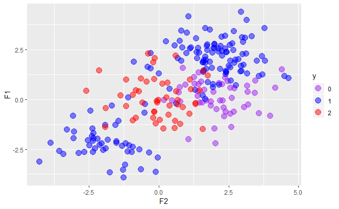

```r
# Plot and see the newly generated `0` class in purple
# Original data from sim_data200 remains same (blue/red dots)
sim_data250 %>%
  ggplot(aes(x = F2, y = F1, colour = y)) +
  geom_point(alpha = 0.5, size = 4) +
  scale_colour_manual(values = c("purple", "blue", "red")) +
  NULL
```

```r
svm_3class <- e1071::svm(y ~ ., data = sim_data250, kernel = "radial",
                         cost = 10, gamma = 1)
summary(svm_3class)
```

```
Call:
svm(formula = y ~ ., data = sim_data250, kernel = "radial", cost = 10,
    gamma = 1)


Parameters:
   SVM-Type:  C-classification
 SVM-Kernel:  radial
       cost:  10
      gamma:  1

Number of Support Vectors:  105

 ( 30 38 37 )


Number of Classes:  3

Levels:
 0 1 2
```

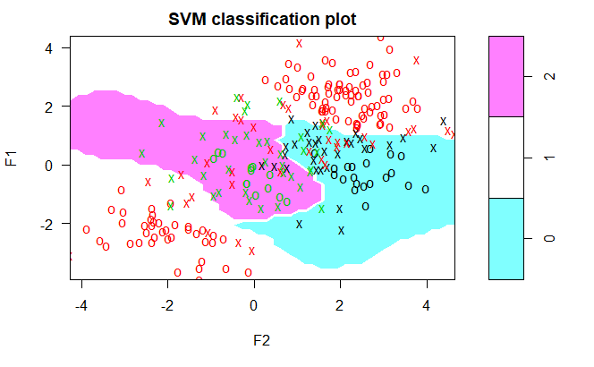

```r
plot(svm_3class, sim_data250)
```

# 4 ROC curves

Typically class predictions are generated for a given probability cutoff, typically 0.5. Receiver Operator Criterion ([ROC](https://en.wikipedia.org/wiki/Receiver_operating_characteristic)) curves can be seen as representing the performance of a classifier for *all possible cutoffs*. With *sensitivity* (true positives) in [0, 1] and *1-specificity* (false positivies) also in [0,1], the total plotting area is 1.0, and the “area under the curve” (AUC) can be used as a performance metric. For SVM, the usual cutoff for determine the class would be zero. The ISLR text uses the `ROCR` to generate ROC curves, we will use a somewhat newer, more popular(?), package … `pROC`.

## 4.1 Using `pROC::roc()`

We use the `pROC::roc()` function to generate a ROC curve for the optimal SVM, with $\gamma = 2$ and `cost = 1`.

```r
# To obtain class probabilities rather than class predictions, use the decision.values = TRUE argument
svm_optimal <- e1071::svm(y ~ ., data = svm_train, kernel = "radial",
                          gamma = 2, cost = 1, decision.values = TRUE)
# These "probabilities" are actually ratios
train_prob <- predict(svm_optimal, newdata = svm_train,
                      decision.values = TRUE) %>%
  attributes() %>%                      # prob ratios are "hidden" in the attributes
  purrr::pluck("decision.values") %>%   # in a list element called `decision.values`
  as.numeric()                          # in a nx1 matrix; we need a vector
roc_train <- pROC::roc(response = svm_train$y,
                       predictor = train_prob,
                       levels = c("1", "2"))
pROC::auc(roc_train)               # AUC
```

```
Area under the curve: 0.9543
```

```r
# ROC curve via S3 plot method
roc_train %>%
  plot(col = "navy",
       main = "Training (blue); Test (red)",
       print.thres = c(-1, 0, 0.5, 1.0),   # 4 arbitrarily chosen cutoffs
       print.thres.cex = 0.8,              # size of the text
       legacy.axes = TRUE,                 # traditionally 1 - spec if plotted
       print.thres.pattern = "cut = %.2f (Spec = %.2f, Sens = %.2f)")
test_prob <- predict(svm_optimal, newdata = svm_test,
                     decision.values = TRUE) %>%
  attributes() %>%
  purrr::pluck("decision.values") %>%
  as.numeric()
roc_test <- pROC::roc(response = svm_test$y,
                      predictor = test_prob,
                      levels = c("1", "2"))
pROC::auc(roc_test)               # AUC
```

```
Area under the curve: 0.9328
```

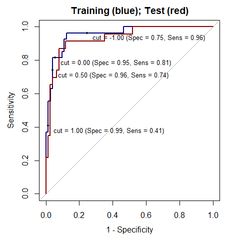

```r
roc_test %>%
  plot(col = "darkred",            # red is test ROC
       add = TRUE,                 # add to existing plot; navy = training
       legacy.axes = TRUE)
```

**Recall that:**

> - Sensitivity = true positive rate
> - 1-specificity = false positive rate

## 4.2 Using `ggplot2` to generate ROC curves

This code is not run, but shows one way to generate ROC curves using `ggplot2`.

```r
ggroc <- function(roc, showAUC = TRUE, interval = 0.2,
                  breaks = seq(0, 1, interval)) {
  if ( !inherits(roc, "roc") ) {
    simpleError("Please provide roc object from `pROC` package.")
  }
  plotx <- rev(roc$specificities)
  ploty <- rev(roc$sensitivities)

  ggplot(NULL, aes(x = plotx, y = ploty)) +
    geom_segment(aes(x = 0, y = 1, xend = 1,yend = 0), alpha = 0.5) +
    geom_step() +
    scale_x_reverse(name = "Specificity",limits = c(1, 0),
                    breaks = breaks, expand = c(0.001, 0.001)) +
    scale_y_continuous(name = "Sensitivity", limits = c(0, 1),
                       breaks = breaks, expand = c(0.001, 0.001)) +
    theme(axis.ticks = element_line(color = "grey80")) +
    coord_equal() +
    annotate("text", x = interval / 2, y = interval / 2, vjust = 0,
             label = paste("AUC =", sprintf("%.3f", roc$auc)))
}
```

Created on 2019-01-14 by [Rmarkdown](https://github.com/rstudio/rmarkdown) (v1.11) and R version 3.5.2 (2018-12-20).